# 2024 BANA 2080 FinalProject

Ryan Morris

2024-12-10

## Final Project Report - Regork Phone/Internet Consumer Analysis

### Introduction

#### Insights into Consumer Churning

Customer retention is a critical aspect of Regork’s success in the highly competitive telecommunications market. Understanding why customers leave and how to prevent it can significantly impact profitability, as retaining current customers is often more cost-effective than acquiring new ones. This analysis seeks to address the pressing question: What steps can we take to better retain our customers?

To tackle this challenge, we analyze a dataset containing customer demographics, service usage, billing details, and retention status. We employ machine learning methodologies, including MARS, Bagged Trees, and Random Forest, to identify key factors influencing customer churn. These insights will allow us to develop a predictive model that can pinpoint customers at risk of leaving.

The insights and tools generated from this analysis will equip Regork with actionable strategies to enhance customer loyalty. By identifying churn-prone customers and understanding their motivations, we can offer targeted incentives and improve service offerings, ensuring long-term customer satisfaction and retention.

### Packages/Libraries Required

#### The following packages and libraries were used:

- `tidyverse` - A collection of open-source packages that offer methods to import, tidy, manipulate, and visualize data.
- `knitr` - Offers methods to help generate reports within R markdown
- `ggplot2` - part of tidyverse, this package offers several methods to help display data in a variety of geoms
- `tidymodels` - A suite of packages designed for machine learning and statistical modeling workflows, emphasizing a unified and tidy approach.
- `vip` - Short for “Variable Importance Plots,” this package provides tools to interpret machine learning models by visualizing the importance of predictors.
- `baguette` - Extends the tidymodels framework to implement ensemble modeling techniques like bagged trees, boosting predictive accuracy.
- `pdp` - Provides tools to create Partial Dependence Plots (PDPs), helping visualize the relationship between features and predictions in machine learning models.
- `kernlab` - A package for kernel-based machine learning algorithms.
- `yardstick` - Used for evaluating and comparing model performance

```r
# Helper packages
library(tidyverse) # for data wrangling & plotting

# Modeling packages
library(tidymodels)

# Model interpretability packages
library(vip)
library(baguette)
library(pdp)
library(kernlab)
library(yardstick)
```

### Data Aggregation and Tidying

Our data looks at our response variable ‘Status’ which tells us whether the customer is currently with us or has left. It has twenty potential predictor variables along side that, that may help paint the picture of the which customers will churn. Before diving in, we want to note that 11 customers were removed from the dataset. Their tenure with our company was 0, which means that they just signed up with us and haven’t faced the decision to churn yet.

```r
retention <- read_csv("data/customer_retention.csv")
retention <- retention %>%
  mutate(Status = factor(Status)) %>%
  mutate(StatusDummy = ifelse(Status == "Current", 1, 0),
         InternetServDummy = ifelse(InternetService != "No", "Yes", "No"))
#Eleven records with tenure = 0 were removed, as these customers have not yet faced the decision to churn.
retention <- retention %>%
  filter(Tenure != 0)
```

```r
# Format any Negative Text values to simple "No"
for (column in colnames(retention)) {
  for (i in 1:nrow(retention)) {  # Loop through each row of the column
    if (retention[i, column] == "No phone service" || retention[i, column] == "No internet service") {
      retention[i, column] <- "No"  # Replace with "No"
    }
  }
}
```

```r
for (column in colnames(retention)) {
  # Check if the column is numeric
  if (class(retention[[column]]) == "numeric") {
    print(paste("Correlation test for:", column))
    print(cor.test(retention[[column]], retention$StatusDummy))
  }
  # If the column is not numeric
  else {
    print(paste("Chi-square test for:", column))
    tableChiSqr <- table(retention[[column]], retention$Status)
    print(chisq.test(tableChiSqr))
  }
}
```

```
## [1] "Chi-square test for: Gender"
##
##  Pearson's Chi-squared test with Yates' continuity correction
##
## data:  tableChiSqr
## X-squared = 0.57516, df = 1, p-value = 0.4482
##
## [1] "Correlation test for: SeniorCitizen"
##
##  Pearson's product-moment correlation
##
## data:  retention[[column]] and retention$StatusDummy
## t = -12.715, df = 6986, p-value < 2.2e-16
## alternative hypothesis: true correlation is not equal to 0
## 95 percent confidence interval:
##  -0.1732314 -0.1273977
## sample estimates:
##        cor
## -0.1503954
##
## [1] "Chi-square test for: Partner"
##
##  Pearson's Chi-squared test with Yates' continuity correction
##
## data:  tableChiSqr
## X-squared = 155.99, df = 1, p-value < 2.2e-16
##
## [1] "Chi-square test for: Dependents"
##
##  Pearson's Chi-squared test with Yates' continuity correction
##
## data:  tableChiSqr
## X-squared = 186, df = 1, p-value < 2.2e-16
##
## [1] "Correlation test for: Tenure"
##
##  Pearson's product-moment correlation
##
## data:  retention[[column]] and retention$StatusDummy
## t = 31.558, df = 6986, p-value < 2.2e-16
```

[output cut: 128 more lines]

```
## data:  retention[[column]] and retention$StatusDummy
## t = Inf, df = 6986, p-value < 2.2e-16
## alternative hypothesis: true correlation is not equal to 0
## 95 percent confidence interval:
##  1 1
## sample estimates:
## cor
##   1
##
## [1] "Chi-square test for: InternetServDummy"
##
##  Pearson's Chi-squared test with Yates' continuity correction
##
## data:  tableChiSqr
## X-squared = 359.59, df = 1, p-value < 2.2e-16
```

### Speculative Analysis

#### Speculated Relationships

As we move forward into this analysis, we wanted to start by speculating on how the variables in this dataset may relate to whether a customer leaves or not. We took this in three directions.

First, we wanted to understand the relationship between length of tenure and churning. The data imaged below is split into categories based on which services the customer utilized. What these graphs show is a tendency for those who decided to churn having shorter tenures. This is especially evident in our phone service where there is a steep drop off after the first year that persists in the rest of the data range. This may imply that once a customer has decided to stick with us for a few years, there is a good chance we can keep them as customers.

- **Tenure Length**

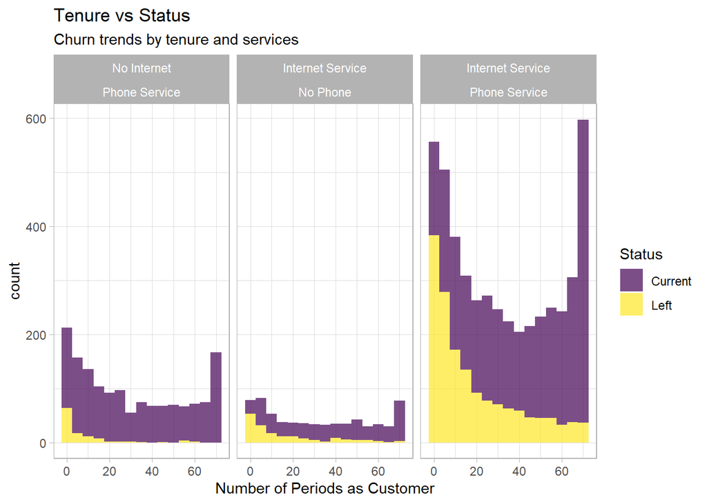

```r
#Exploring Relationships between
retention %>%
  ggplot(aes(x = Tenure, fill = Status)) +
  geom_histogram(binwidth = 5, position = "stack", alpha = 0.7) +
  facet_wrap(~ InternetServDummy + PhoneService,
             labeller = labeller(
               InternetServDummy = c("No" = "No Internet", "Yes" = "Internet Service"),
               PhoneService = c("No" = "No Phone", "Yes" = "Phone Service")
             )) +
  labs(title = "Tenure vs Status",
        subtitle = "Churn trends by tenure and services",
        x = "Number of Periods as Customer",
        fill = "Status") +
  theme_light() +
  scale_fill_ordinal()
```

- **Internet Features**

The next relationship we wanted to explore was that between the number internet features and tendency to churn. We split this between our DSL and Fiber Optics consumers to make sure we see if there is any visible variance between the two. Both services show a similar trend. Customers with 2+ of our service additions have a higher tendency to stay than those with 0-1. That is even more prevalent for customers who are taking advantage of 5 or all 6.

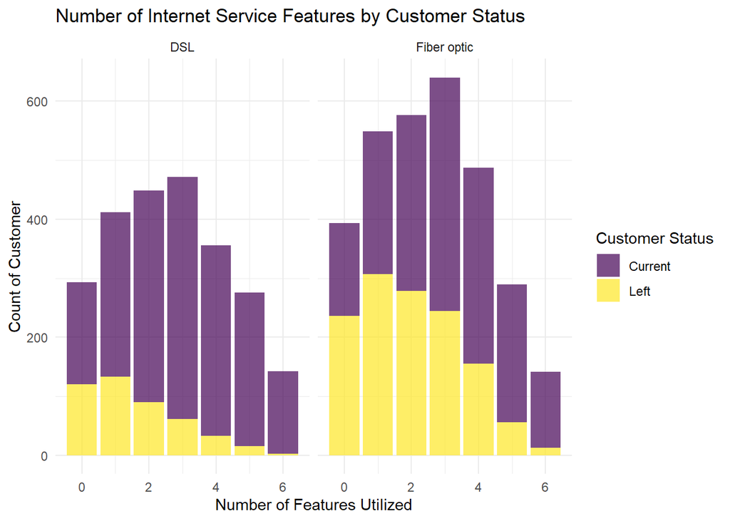

```r
InternetFeatRetention <- retention %>%
  filter(InternetService != "No") %>%
  mutate(FeatureCount = 0)

# Calculate FeatureCount using row-wise sums of conditions
InternetFeatRetention$FeatureCount <- rowSums(InternetFeatRetention[,
    c("OnlineSecurity", "OnlineBackup",  "DeviceProtection", "TechSupport", "StreamingTV", "StreamingMovies")] == "Yes")

InternetFeatRetention %>%
  ggplot(aes(x = FeatureCount, fill = Status)) +
  geom_bar(position = "stack", alpha = 0.7) +
  facet_wrap(~InternetService) +
  labs(title = "Number of Internet Service Features by Customer Status",
       x = "Number of Features Utilized",
       y = "Count of Customer",
       fill = "Customer Status") +
  theme_minimal() +
  scale_fill_ordinal()
```

- **Partners and Dependents**

The last relationship we wanted to understand was the likelihood of household with multiple individuals churning. Our data has information on multiperson household split into two categories: those with/without partners and those with/without dependents. For this top level view, we opted to look at both categories individually, but one thing to keep in mind is that these two graphs have some redundancy. This first graph is for Partners, and see that those with Partners are less likely to churn. The second looks at dependents, and we see the same story. While this isn’t definitive, we can start to understand that there is a relationship for customers using the service with multiple household members.

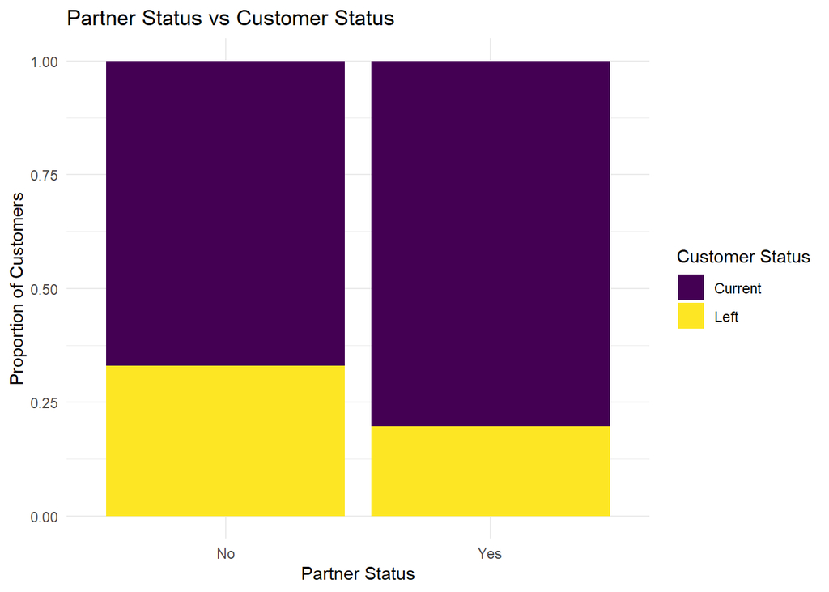

```r
# Plot for Partner vs Churn
retention %>%
  ggplot(aes(x = Partner, fill = Status)) +
  geom_bar(position = "fill") +  # Use 'fill' to show proportion
  labs(title = "Partner Status vs Customer Status",
       x = "Partner Status",
       y = "Proportion of Customers",
       fill = "Customer Status") +
  scale_fill_ordinal() +
  theme_minimal()
```

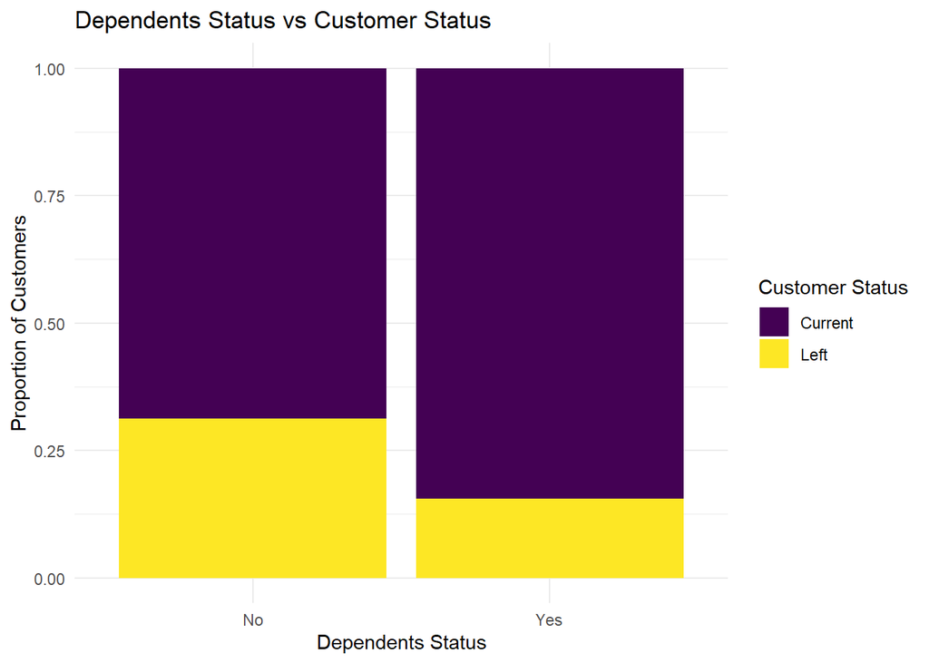

```r
# Plot for Dependents vs Churn
retention %>%
  ggplot(aes(x = Dependents, fill = Status)) +
  geom_bar(position = "fill") +  # Use 'fill' to show proportion
  labs(title = "Dependents Status vs Customer Status",
       x = "Dependents Status",
       y = "Proportion of Customers",
       fill = "Customer Status") +
  scale_fill_ordinal() +
  theme_minimal()
```

### Machine Learning Models

#### MARS

We began with a Multivariate Adaptive Regression Splines (MARS) model to assess its classification performance.

```r
retentionOne <- read_csv("data/customer_retention.csv")
retentionOne <- retentionOne %>%
  mutate(Status = factor(Status)) %>%
  filter(Tenure != 0)

set.seed(123)
split  <- rsample::initial_split(retentionOne, prop = 0.7, strata = "Status")
reten_train  <- rsample::training(split)
reten_test   <- rsample::testing(split)

mars_mod <- mars(mode = "classification", num_terms = tune(), prod_degree = tune())

set.seed(123)
folds <- vfold_cv(reten_train, v = 5, strata = "Status")

model_recipe <- recipe(Status ~ ., data = reten_train)

hyper_grid <- grid_regular(
 num_terms(range = c(1, 50)),
 prod_degree(),
 levels = 50
 )

results <- tune_grid(mars_mod, model_recipe, resamples = folds, grid = hyper_grid)

show_best(results, metric = "roc_auc")
```

```
## # A tibble: 5 × 8
##   num_terms prod_degree .metric .estimator  mean     n std_err .config
##       <int>       <int> <chr>   <chr>      <dbl> <int>   <dbl> <chr>
## 1        20           1 roc_auc binary     0.850     5 0.00486 Preprocessor1_Mo…
## 2        19           1 roc_auc binary     0.849     5 0.00486 Preprocessor1_Mo…
## 3        18           1 roc_auc binary     0.849     5 0.00486 Preprocessor1_Mo…
## 4        21           1 roc_auc binary     0.849     5 0.00486 Preprocessor1_Mo…
## 5        22           1 roc_auc binary     0.849     5 0.00486 Preprocessor1_Mo…
```

```r
mars_best_hyperparameters <- select_best(results, metric = "roc_auc")

final_mars_wf <- workflow() %>%
  add_recipe(model_recipe) %>%
  add_model(mars_mod) %>%
  finalize_workflow(mars_best_hyperparameters)

mars_final_fit <- final_mars_wf %>%
  fit(data = reten_train)

mars_final_fit %>%
   predict(reten_test) %>%
   bind_cols(reten_test %>% select(Status)) %>%
   conf_mat(truth = Status, estimate = .pred_class)
```

```
##           Truth
## Prediction Current Left
##    Current    1383  242
##    Left        157  315
```

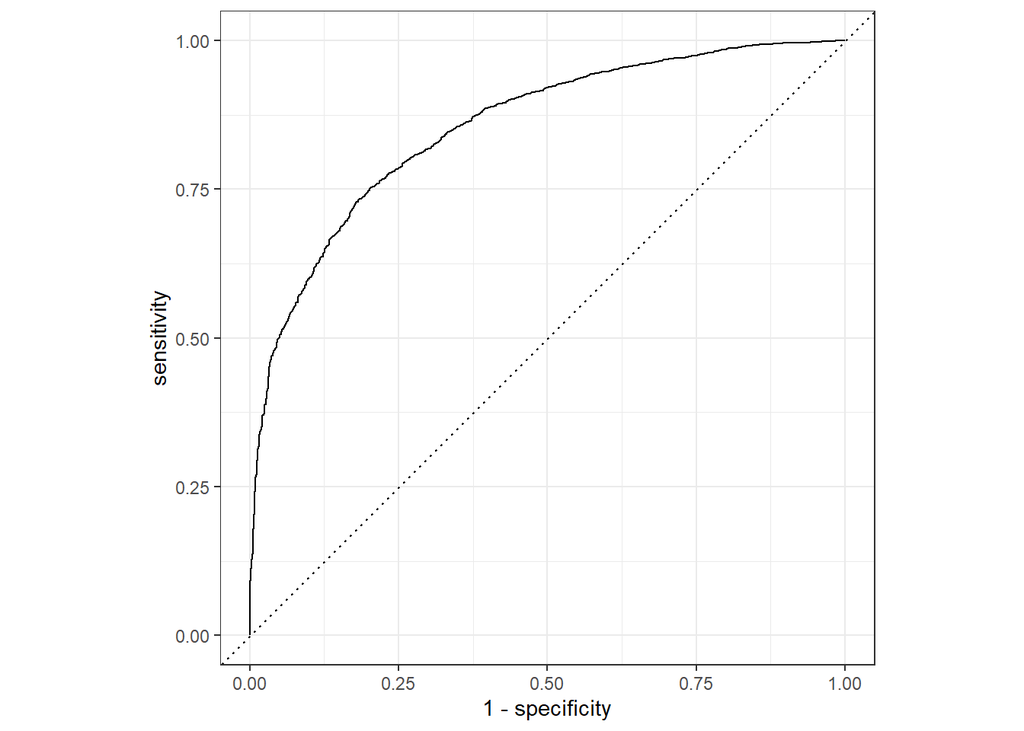

```r
mars_final_fit %>%
  predict(reten_train, type = "prob") %>%
  mutate(truth = reten_train$Status) %>%
  roc_curve(truth, .pred_Current) %>%
  autoplot()
```

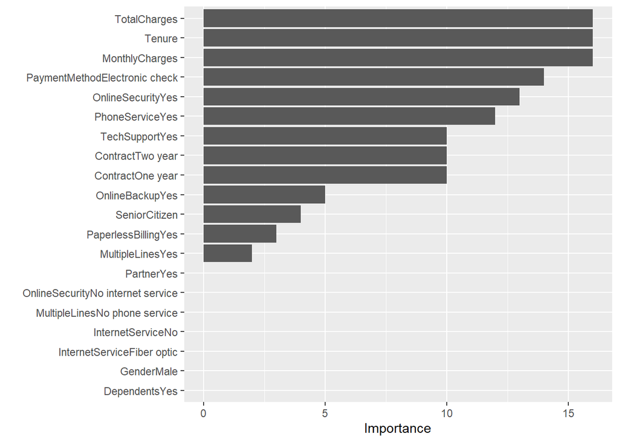

```r
mars_final_fit %>%
  extract_fit_parsnip() %>%
  vip(num_features = 20)
```

**Performance Summary:**

- **Top ROC_AUC:** 84.97%
- **Confusion Matrix:**
  - True Positives: 1383
  - True Negatives: 315
  - False Positives: 242
  - False Negatives: 157

**Key Features:** Total Charges, Tenure, Monthly Charges, Payment Method (Electronic Check), Online Security (Yes).

#### Bagged Tree

We next utlized the Bagged Tree method.

```r
set.seed(123)
bt_train <- reten_train
bt_test <- reten_test
btkfold <- vfold_cv(bt_train, v = 5)

model_recipe <- recipe(Status ~ ., data = bt_train)

bt_mod <- bag_tree() %>%
  set_engine("rpart", times = tune()) %>%
  set_mode("classification")

bt_hyper_grid <- expand.grid(times = c(5, 25, 50, 100))

set.seed(123)
bt_results <- tune_grid(bt_mod, model_recipe, resamples = btkfold, grid = bt_hyper_grid)

show_best(bt_results, metric = "roc_auc", n = 5)
```

```
## # A tibble: 4 × 7
##   times .metric .estimator  mean     n std_err .config
##   <dbl> <chr>   <chr>      <dbl> <int>   <dbl> <chr>
## 1   100 roc_auc binary     0.819     5 0.00991 Preprocessor1_Model4
## 2    50 roc_auc binary     0.816     5 0.00940 Preprocessor1_Model3
## 3    25 roc_auc binary     0.809     5 0.00971 Preprocessor1_Model2
## 4     5 roc_auc binary     0.761     5 0.00974 Preprocessor1_Model1
```

```r
bt_best_hyperparameters <- select_best(bt_results, metric = "roc_auc")

final_bt_wf <- workflow() %>%
  add_recipe(model_recipe) %>%
  add_model(bt_mod) %>%
  finalize_workflow(bt_best_hyperparameters)

bt_final_fit <- final_bt_wf %>%
  fit(data = bt_train)

bt_final_fit %>%
   predict(reten_test) %>%
   bind_cols(reten_test %>% select(Status)) %>%
   conf_mat(truth = Status, estimate = .pred_class)
```

```
##           Truth
## Prediction Current Left
##    Current    1340  262
##    Left        200  295
```

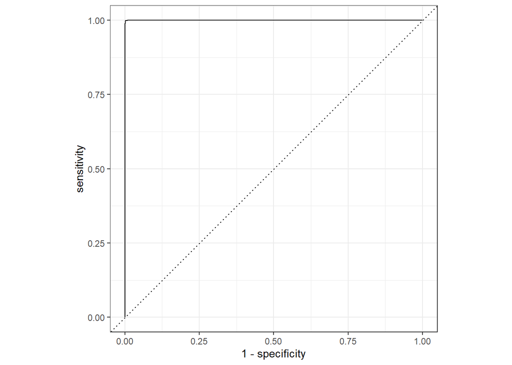

```r
bt_final_fit %>%
  predict(bt_train, type = "prob") %>%
  mutate(truth = bt_train$Status) %>%
  roc_curve(truth, .pred_Current) %>%
  autoplot()
```

**Performance Summary:**

- **Top ROC_AUC:** 81.88%
- **Confusion Matrix:**
  - True Positives: 1340
  - True Negatives: 295
  - False Positives: 262
  - False Negatives: 200

#### Random Forest

And finally, random forest.

```r
rf_mod <- rand_forest(mode = "classification") %>%
  set_engine("ranger")

rf_results <- fit_resamples(rf_mod, model_recipe, btkfold)

collect_metrics(rf_results)
```

```
## # A tibble: 3 × 6
##   .metric     .estimator  mean     n std_err .config
##   <chr>       <chr>      <dbl> <int>   <dbl> <chr>
## 1 accuracy    binary     0.798     5 0.00534 Preprocessor1_Model1
## 2 brier_class binary     0.139     5 0.00338 Preprocessor1_Model1
## 3 roc_auc     binary     0.837     5 0.0100  Preprocessor1_Model1
```

```r
rf_mod <- rand_forest(
  mode = "classification",
  trees = tune(),
  mtry = tune(),
  min_n = tune()
) %>%
  set_engine("ranger", importance = "impurity")

rf_hyper_grid <- grid_regular(
  trees(range = c(50, 800)),
  mtry(range = c(2, 50)),
  min_n(range = c(1, 20))
)

set.seed(123)
rf_results <- tune_grid(rf_mod, model_recipe, resamples = btkfold, grid = rf_hyper_grid)

show_best(rf_results, metric = "roc_auc")
```

```
## # A tibble: 5 × 9
##    mtry trees min_n .metric .estimator  mean     n std_err .config
##   <int> <int> <int> <chr>   <chr>      <dbl> <int>   <dbl> <chr>
## 1     2   800    20 roc_auc binary     0.844     5 0.0104  Preprocessor1_Model21
## 2     2   425    20 roc_auc binary     0.843     5 0.0103  Preprocessor1_Model20
## 3     2   800    10 roc_auc binary     0.842     5 0.0104  Preprocessor1_Model12
## 4     2   425    10 roc_auc binary     0.841     5 0.0104  Preprocessor1_Model11
## 5     2    50    20 roc_auc binary     0.841     5 0.00981 Preprocessor1_Model19
```

```r
rf_best_hyperparameters <- select_best(rf_results, metric = "roc_auc")

final_rf_wf <- workflow() %>%
  add_recipe(model_recipe) %>%
  add_model(rf_mod) %>%
  finalize_workflow(rf_best_hyperparameters)

rf_final_fit <- final_rf_wf %>%
  fit(data = reten_train)

rf_final_fit %>%
   predict(reten_test) %>%
   bind_cols(reten_test %>% select(Status)) %>%
   conf_mat(truth = Status, estimate = .pred_class)
```

```
##           Truth
## Prediction Current Left
##    Current    1396  277
##    Left        144  280
```

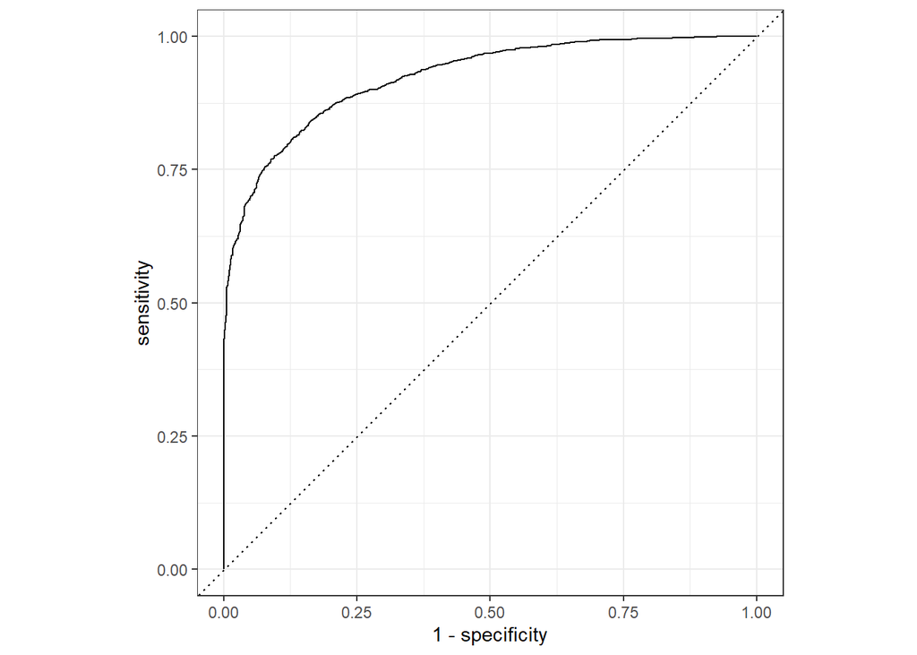

```r
rf_final_fit %>%
  predict(reten_train, type = "prob") %>%
  mutate(truth = reten_train$Status) %>%
  roc_curve(truth, .pred_Current) %>%
  autoplot()
```

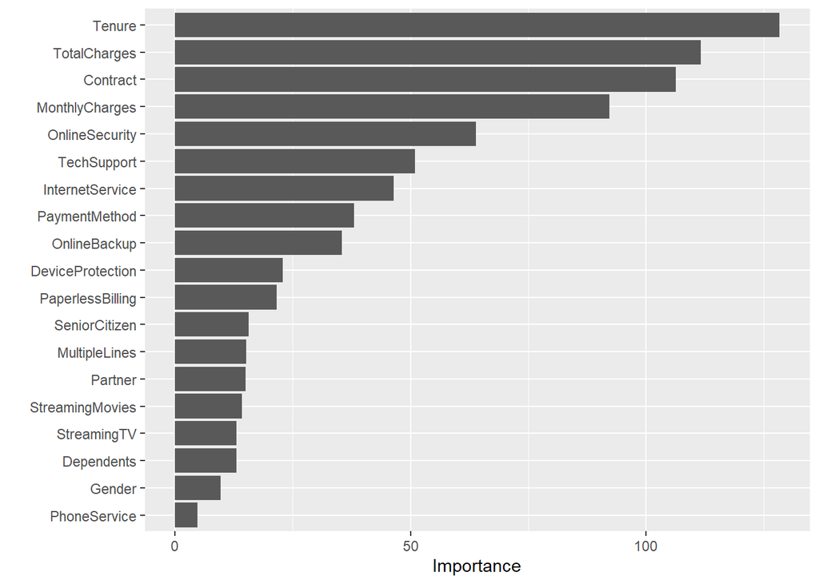

```r
rf_final_fit %>%
  extract_fit_parsnip() %>%
  vip(num_features = 20)
```

**Performance Summary:**

- **Top ROC_AUC:** 84.35%
- **Confusion Matrix:**
  - True Positives: 1396
  - True Negatives: 280
  - False Positives: 277
  - False Negatives: 144

**Key Features:** Tenure, Total Charges, Contract, Monthly Charges, Online Security.

#### MARS - No Tenure

To assess actionable insights, we reran the MARS model without Tenure.

```r
retentionTwo <- retentionOne %>%
  select(-Tenure)

set.seed(123)
split  <- rsample::initial_split(retentionTwo, prop = 0.7, strata = "Status")
reten2_train  <- rsample::training(split)
reten2_test   <- rsample::testing(split)

mars_mod <- mars(mode = "classification", num_terms = tune(), prod_degree = tune())

set.seed(123)
folds2 <- vfold_cv(reten2_train, v = 5, strata = "Status")

model2_recipe <- recipe(Status ~ ., data = reten2_train)

hyper_grid2 <- grid_regular(
 num_terms(range = c(1, 50)),
 prod_degree(),
 levels = 50
 )

results2 <- tune_grid(mars_mod, model2_recipe, resamples = folds2, grid = hyper_grid2)

mars2_best_hyperparameters <- select_best(results2, metric = "roc_auc")

final_mars_wf2 <- workflow() %>%
  add_recipe(model2_recipe) %>%
  add_model(mars_mod) %>%
  finalize_workflow(mars2_best_hyperparameters)

mars2_final_fit <- final_mars_wf2 %>%
  fit(data = reten2_train)

mars2_final_fit %>%
   predict(reten2_test) %>%
   bind_cols(reten2_test %>% select(Status)) %>%
   conf_mat(truth = Status, estimate = .pred_class)
```

```
##           Truth
## Prediction Current Left
##    Current    1378  245
##    Left        162  312
```

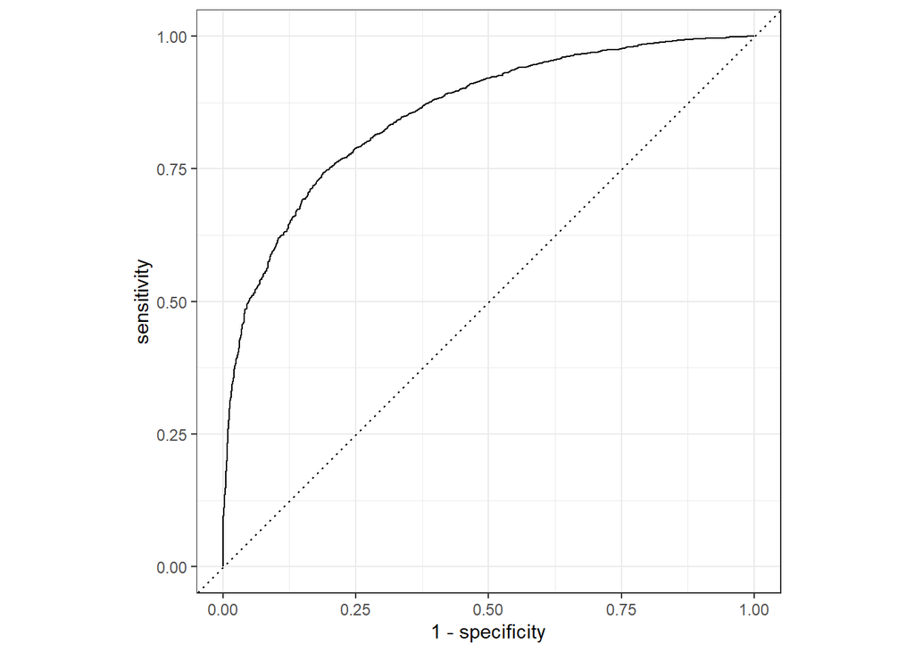

```r
mars2_final_fit %>%
  predict(reten_train, type = "prob") %>%
  mutate(truth = reten_train$Status) %>%
  roc_curve(truth, .pred_Current) %>%
  autoplot()
```

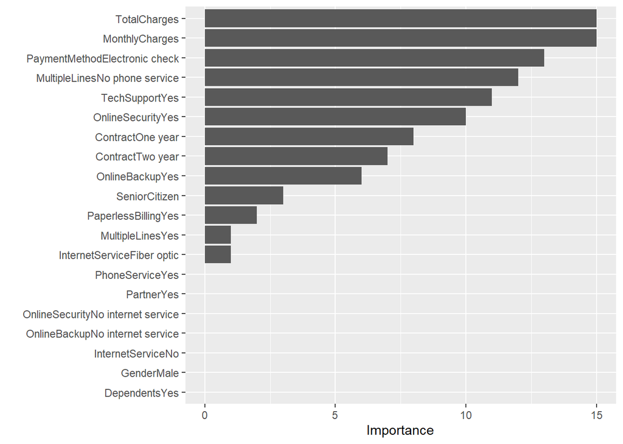

```r
mars2_final_fit %>%
  extract_fit_parsnip() %>%
  vip(num_features = 20)
```

**Performance Summary:**

- **Top ROC_AUC:** 85.00%
- **Confusion Matrix:**
  - True Positives: 1378
  - True Negatives: 312
  - False Positives: 245
  - False Negatives: 162

**Key Features:** Total Charges, Monthly Charges, Payment Method (Electronic Check), Multiple Line (No Phone Service), Tech Support (Yes).

With the results of each model in hand, we concluded that the MARS model without Tenure provided the best balance of actionable insights and predictive performance. By excluding Tenure, we focused on features that can be directly influenced through business strategies, such as payment methods and service enhancements. While the confusion matrices for all models were comparable, the final selected model produced 245 false positives and 162 false negatives. Although these numbers may seem significant, they are within an acceptable range for a predictive model and serve as a solid foundation for further refinement and business insights.

```r
final_model <- mars2_final_fit
```

### Conclusion

#### Key Factors to Focus On:

From the analysis, the most impactful factors influencing customer churn are as follows:

- **Total Charges and Monthly Charges:** Customers with higher bills are more likely to churn, suggesting pricing is a critical pain point.
- **Payment Method - E-Check:** This method is strongly associated with higher churn, indicating customers using E-Check may face unique frustrations or financial challenges.
- **Multiple Line - No Phone Service:** The absence of phone service correlates with churn, potentially highlighting missed opportunities for bundled services or misaligned customer needs.
- **Tech Support - Yes:** Customers who utilize tech support appear to be more likely to churn, possibly reflecting dissatisfaction with service quality or resolution processes.

These variables highlight areas where Regork can focus efforts to improve customer retention by addressing customer pain points, streamlining processes, and enhancing service offerings.

#### Potential Revenue Loss:

```r
retention <- retention %>%
  mutate(churn_prob = predict(final_model, retention, type = "prob")$.pred_Left)
retention <- retention %>%
  mutate(revenue_loss = churn_prob * MonthlyCharges)
total_revenue_loss <- sum(retention$revenue_loss)
print(total_revenue_loss)
```

```
## [1] 136540
```

Based on predictive modeling, Regork stands to lose an estimated $136,540 per month in revenue if no action is taken. This projection is based on the dataset of 6,988 customers and their likelihood of churn. Adjustments would be necessary for a larger or smaller customer base.

#### Incentive Scheme:

To mitigate churn and retain customers, Regork can implement the following incentive program:

- **Price Incentives:**
  - Discounts on bundled services for customers without phone service to encourage subscription to additional services.
  - Temporary price reductions for high-risk customers (identified through predictive modeling).
- **Payment Support:**
  - Streamlined payment options with clear communication and education for E-Check users.
  - Promotional incentives for customers switching to more reliable payment methods (e.g., auto-pay via credit/debit card).
- **Tech Support Revamp:**
  - Enhanced training for tech support staff to improve customer interactions.
  - Proactive outreach to customers who frequently use tech support to address unresolved concerns or frustrations.

#### Implications for Regork and Proposed Actions for the CEO:

The analysis suggests that pricing, payment processing, and service quality are pivotal areas requiring immediate attention. Implementing the proposed retention strategy would likely mitigate revenue loss and improve customer satisfaction.

**Recommendations for the CEO:**

- **Price Sensitivity Review:** Conduct market analysis to benchmark service pricing against competitors and evaluate bundling discounts.
- **Payment Method Overhaul:** Investigate pain points specific to E-Check and introduce user-friendly payment processes.
- **Customer Support Audit:** Review tech support team performance, focusing on recurring issues, resolution time, and customer feedback.

#### Limitations of Analysis

1. **Data Scope:** The analysis is limited to the dataset provided, which may not fully represent Regork’s current customer base. Expanding the dataset with recent and broader customer information could enhance predictions.
2. **Excluded Variables:** Certain potentially influential factors, such as regional variations, competitor influences, or service availability, were not included in the dataset. A portion of the customer base may reside in areas where Regork’s services are not consistently offered or supported, leading to higher churn rates. Future analyses should consider integrating geographic data to address these gaps.
3. **Customer Feedback:** The absence of qualitative data on customer experiences limits insights into underlying causes of dissatisfaction. Gathering and analyzing customer feedback, especially from regions with limited service availability, could help identify overlooked issues and inform targeted interventions.